# Most deadly terrorist organizations

Piotr Sobczyk

March 31, 2016

We select only those attacks, that undoubtly were done by terrorist and that were deadly.

```r
terrorism <- read.csv("globalterrorism_selected_cols_0615.csv")
terrorism$decade <- floor(terrorism$iyear/10)%%10
terrorism %>% filter(doubtterr==0, nkill>0) -> confirmed.deadly.terrorism
summary(confirmed.deadly.terrorism)
```

```
##      iyear          imonth            iday          country
##  Min.   :1970   Min.   : 0.000   Min.   : 0.00   Min.   :   4.0
##  1st Qu.:1992   1st Qu.: 4.000   1st Qu.: 8.00   1st Qu.:  92.0
##  Median :2008   Median : 7.000   Median :15.00   Median :  95.0
##  Mean   :2003   Mean   : 6.589   Mean   :15.55   Mean   : 128.5
##  3rd Qu.:2012   3rd Qu.:10.000   3rd Qu.:23.00   3rd Qu.: 160.0
##  Max.   :2014   Max.   :12.000   Max.   :31.00   Max.   :1004.0
##
##       country_txt                         region_txt           city
##  Iraq       : 9148   Middle East & North Africa:14618   Baghdad  : 3299
##  Afghanistan: 4439   South Asia                :13607   Unknown  : 1581
##  Pakistan   : 4043   Sub-Saharan Africa        : 4681   Karachi  :  886
##  India      : 3361   South America             : 4236   Belfast  :  773
##  Colombia   : 2179   Southeast Asia            : 3193   Mosul    :  772
##  Peru       : 1745   Western Europe            : 2660   Mogadishu:  493
##  (Other)    :21166   (Other)                   : 3086   (Other)  :38277
##       latitude       longitude          suicide            crit1
##           : 8600   Min.   :-157.97   Min.   :0.00000   Min.   :0.0000
##  33.3     : 1150   1st Qu.:   6.60   1st Qu.:0.00000   1st Qu.:1.0000
##  54.597269:  784   Median :  44.39   Median :0.00000   Median :1.0000
##  36.34    :  566   Mean   :  30.68   Mean   :0.06638   Mean   :0.9999
##  24.893379:  353   3rd Qu.:  67.01   3rd Qu.:0.00000   3rd Qu.:1.0000
##  33.75    :  322   Max.   : 177.85   Max.   :1.00000   Max.   :1.0000
##  (Other)  :34306   NA's   :8601
##      crit2       crit3     doubtterr
##  Min.   :0   Min.   :0   Min.   :0
##  1st Qu.:1   1st Qu.:1   1st Qu.:0
##  Median :1   Median :1   Median :0
##  Mean   :1   Mean   :1   Mean   :0
##  3rd Qu.:1   3rd Qu.:1   3rd Qu.:0
##  Max.   :1   Max.   :1   Max.   :0
##
##                        attacktype1_txt                    weaptype1_txt
##  Bombing/Explosion             :17606   Firearms                 :22879
##  Armed Assault                 :15053   Explosives/Bombs/Dynamite:18644
##  Assassination                 : 9318   Unknown                  : 3004
##  Hostage Taking (Kidnapping)   : 1850   Melee                    : 1076
##  Unknown                       : 1595   Incendiary               :  402
##  Facility/Infrastructure Attack:  377   Chemical                 :   29
##  (Other)                       :  282   (Other)                  :   47
```

[output cut: 73 more lines]

```
##                                                                                                 :14816
##  "Iraq: Roundup of Security Incidents 18-24 March 2014," OSC Summary, March 25, 2014.           :   38
##  National Counter Terrorism Center, 2006 Report on Terrorism                                    :   36
##  National Counter Terrorism Center, 2007 Report on Terrorism                                    :   29
##  "Iraq: Roundup of Security Incidents 13-19 May 2014," OSC Summary, May 20, 2014.               :   28
##  "Qaeda claims latest deadly Iraq attacks," Agence France Presse -- English, September 10, 2012.:   28
##  (Other)                                                                                        :31106
##      decade
##  Min.   :0.000
##  1st Qu.:1.000
##  Median :1.000
##  Mean   :3.229
##  3rd Qu.:8.000
##  Max.   :9.000
##
```

What are the most deadly terrorist organizations of all time, which ones organized most attacks?

|  | gname | total_kills | total_attacks |
| --- | --- | --- | --- |
| 1 | Unknown | 72881.86 | 20525 |
| 2 | Taliban | 12270 | 2705 |
| 3 | Boko Haram | 10115.6 | 872 |
| 4 | Shining Path (SL) | 8072 | 1603 |
| 5 | Islamic State of Iraq and the Levant (ISIL) | 7474.33 | 899 |
| 6 | Liberation Tigers of Tamil Eelam (LTTE) | 6549 | 747 |
| 7 | Tehrik-i-Taliban Pakistan (TTP) | 4047 | 532 |
| 8 | Al-Qa`ida in Iraq | 3745.8 | 470 |
| 9 | Revolutionary Armed Forces of Colombia (FARC) | 3641 | 824 |
| 10 | Al-Qa`ida | 3518 | 34 |

[output cut: 10 more lines]

For future reference, data is more complete when it comes to the type of weapon used. This indicates, that database is more or less complete, and on many occasions this is in fact difficult to put the blaim on somebody.

|  | weaptype1_txt | total_kills | total_attacks |
| --- | --- | --- | --- |
| 1 | Explosives/Bombs/Dynamite | 101104.595 | 18644 |
| 2 | Firearms | 87738.1050000001 | 22879 |
| 3 | Unknown | 18244.37 | 3004 |
| 4 | Melee | 10787.83 | 1076 |
| 5 | Incendiary | 4034.6799999766 | 402 |
| 6 | Chemical | 408 | 29 |
| 7 | Vehicle (not to include vehicle-borne explosives, i.e., car or truck bombs) | 67 | 21 |
| 8 | Sabotage Equipment | 34 | 6 |
| 9 | Other | 29 | 14 |
| 10 | Biological | 9 | 6 |

It might be interesting to visualize this results by grouping it with respect to either a region that given organization is present in, or by its ideology.

#### Unknowns

Let us focus more on those attacks for whom nobody take responsibility - ’unknown’s.

where are unknown from? What percentage of attacks is unknown as a percentage of all attacks in regions?

|  | region_txt | decade | percent_unknown | count_unknown | kill_unknown | percent_kill_unknown |
| --- | --- | --- | --- | --- | --- | --- |
| 1 | Australasia &amp; Oceania | 0 | 0 | 0 | 0 | 0 |
| 2 | Australasia &amp; Oceania | 1 | 0 | 0 | 0 | 0 |
| 3 | Eastern Europe | 7 | 0 | 0 | 0 | 0 |
| 4 | East Asia | 7 | 0.25 | 1 | 25 | 0.862068965517241 |
| 5 | Eastern Europe | 8 | 0.333333333333333 | 2 | 6 | 0.545454545454545 |
| 6 | Western Europe | 1 | 0.0952380952380952 | 2 | 3 | 0.0283018867924528 |
| 7 | Australasia &amp; Oceania | 9 | 0.375 | 3 | 3 | 0.111111111111111 |
| 8 | East Asia | 8 | 0.333333333333333 | 3 | 26 | 0.722222222222222 |
| 9 | South Asia | 7 | 0.125 | 3 | 10 | 0.10752688172043 |
| 10 | Australasia &amp; Oceania | 8 | 0.5 | 5 | 15 | 0.384615384615385 |

[output cut: 47 more lines]

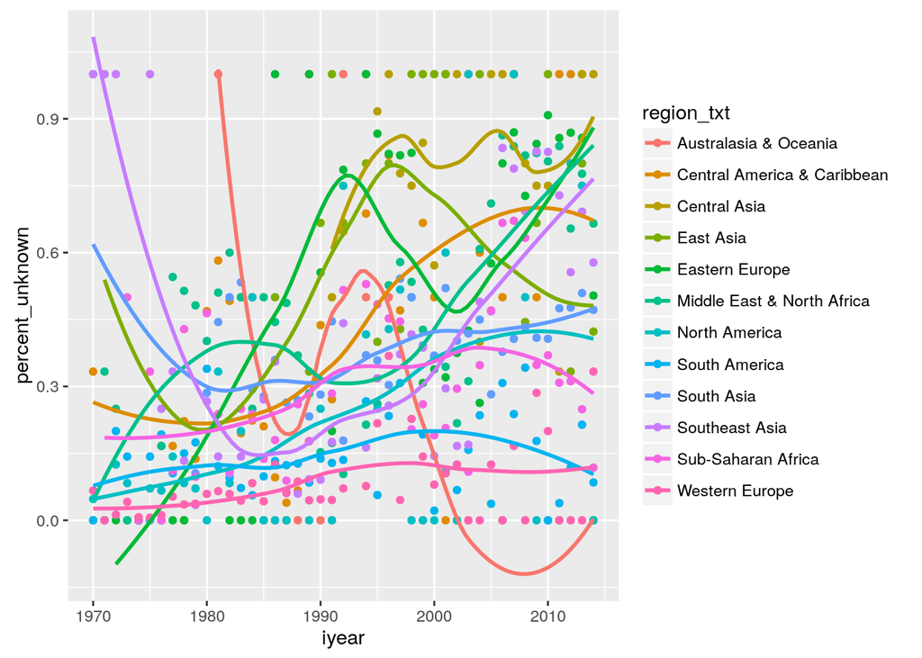

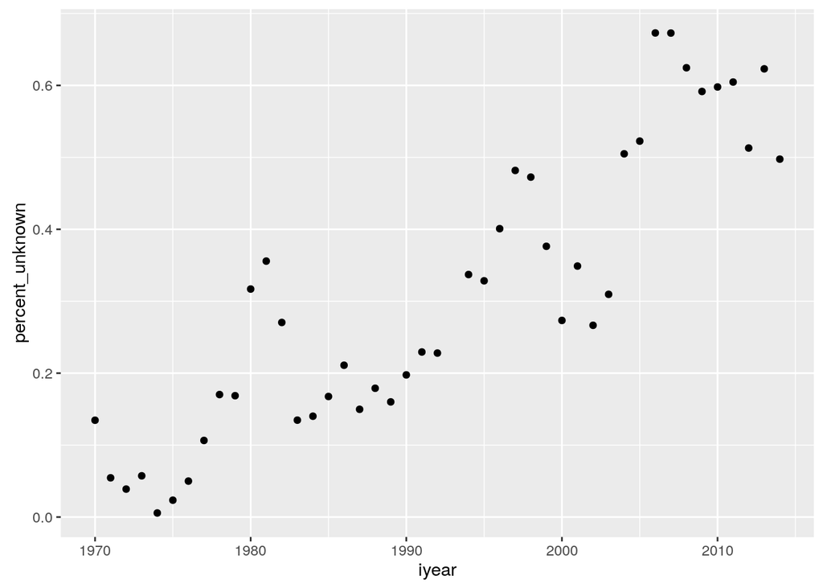

Some hypothesis:

act together? Right now, the threat to Western Europe is well known, but it does not bring it closer to solution.

##### Nothing is anonymous in well developed parts of the world.

One reason could be that database is maintained by people from the “west”.

Other is that there is no source of information about attacks

```r
confirmed.deadly.terrorism %>% group_by(gname=='Unknown', scite1=="") %>% summarise(n())
```

```
## Source: local data frame [4 x 3]
## Groups: gname == "Unknown" [?]
##
##   gname == "Unknown" scite1 == ""   n()
##                (lgl)        (lgl) (int)
## 1              FALSE        FALSE 14158
## 2              FALSE         TRUE 11398
## 3               TRUE        FALSE 17107
## 4               TRUE         TRUE  3418
```

Maybe those attacks are really small and that’s why nobody investigates them close enough?

```r
confirmed.deadly.terrorism %>% group_by(nkill>10, gname=='Unknown') %>% summarise(n())
```

```
## Source: local data frame [4 x 3]
## Groups: nkill > 10 [?]
##
##   nkill > 10 gname == "Unknown"   n()
##        (lgl)              (lgl) (int)
## 1      FALSE              FALSE 22531
## 2      FALSE               TRUE 19224
## 3       TRUE              FALSE  3025
## 4       TRUE               TRUE  1301
```

It seems that the only exlanatory variable here is region. Let us verify it by building a logisitc model.

```r
fit <- glm((gname=='Unknown')~region_txt+suicide+attacktype1_txt,
        family = "binomial", data = confirmed.deadly.terrorism)
summary(fit)$coefficients %>% data.frame() %>% datatable()
```

|  | Estimate | Std..Error | z.value | Pr...z.. |
| --- | --- | --- | --- | --- |
| (Intercept) | -0.656336779656108 | 0.455298342455694 | -1.44155319370612 | 0.149428460837294 |
| region_txtCentral America &amp; Caribbean | -0.174454311916293 | 0.458341444312791 | -0.380620853909161 | 0.703484604867831 |
| region_txtCentral Asia | 1.90178113888691 | 0.499272603083399 | 3.80910373840248 | 0.000139471436142372 |
| region_txtEast Asia | 0.604468519012744 | 0.496783139486809 | 1.21676536695101 | 0.223693500520963 |
| region_txtEastern Europe | 1.09888874864323 | 0.459775493460323 | 2.39005506877468 | 0.0168458467010108 |
| region_txtMiddle East &amp; North Africa | 1.09556847117526 | 0.455390907464541 | 2.40577590201572 | 0.0161381608426032 |
| region_txtNorth America | -0.578097731775259 | 0.474348935965274 | -1.21871830617447 | 0.222951127422696 |
| region_txtSouth America | -1.35933587202576 | 0.457134455067752 | -2.97360187348882 | 0.00294326686488196 |
| region_txtSouth Asia | 0.243457569010477 | 0.455367244903996 | 0.53464005532898 | 0.592898780067837 |
| region_txtSoutheast Asia | 0.629012689711377 | 0.456402354153109 | 1.3781977327408 | 0.168142247083904 |

[output cut: 11 more lines]

We need to be carefull with interpretation.